# 重賞レース予測レポート【毎時自動更新中】

作成日時: 2026/04/19 09:07:44

☞ [マニュアル(pdf)](https://ryutoro-galois.github.io/keiba-predictor/manual/manual.pdf)

☞ 過去6年の同一レース結果: [2025年](https://ryutoro-galois.github.io/keiba-predictor/report/PredResult_2025y_raceDate_20250419_20250420.html), [2024年](https://ryutoro-galois.github.io/keiba-predictor/report/PredResult_2024y_raceDate_20240413_20240414.html), [2023年](https://ryutoro-galois.github.io/keiba-predictor/report/PredResult_2023y_raceDate_20230415_20230416.html), [2022年](https://ryutoro-galois.github.io/keiba-predictor/report/PredResult_2022y_raceDate_20220416_20220417.html), [2021年](https://ryutoro-galois.github.io/keiba-predictor/report/PredResult_2021y_raceDate_20210417_20210418.html), [2020年](https://ryutoro-galois.github.io/keiba-predictor/report/PredResult_2020y_raceDate_20200418_20200419.html)

☞ 過去4週間の別レース結果: [1週前(4/11-12)](https://ryutoro-galois.github.io/keiba-predictor/report/PredResult_2026y_raceDate_20260411_20260412.html), [2週前(4/4-5)](https://ryutoro-galois.github.io/keiba-predictor/report/PredResult_2026y_raceDate_20260404_20260405.html), [3週前(3/28-29)](https://ryutoro-galois.github.io/keiba-predictor/report/PredResult_2026y_raceDate_20260328_20260329.html), [4週前(3/21-22)](https://ryutoro-galois.github.io/keiba-predictor/report/PredResult_2026y_raceDate_20260321_20260322.html)

☞ netkeiba: [中山グランドジャンプ(JGⅠ)](https://race.netkeiba.com/race/shutuba.html?race_id=202606030711&rf=race_list), [アンタレスステークス(GⅢ)](https://race.netkeiba.com/race/shutuba.html?race_id=202609020711&rf=race_list), [皐月賞(GⅠ)](https://race.netkeiba.com/race/shutuba.html?race_id=202606030811&rf=race_list), [福島牝馬ステークス(GⅢ)](https://race.netkeiba.com/race/shutuba.html?race_id=202603010411&rf=race_list)

## 0. 推し馬予測 (AI予測)

### 【中山グランドジャンプ(J.GⅠ) 2026/04/18(土)】

- 本命(◎): 1-3着内確率(勝負強さ)が1位の馬
- 対抗(◯): 1-3着内確率が2-N位(20%程度以上)の中で予測タイムが最も速い馬
- 3番手(▲): 1-3着内確率が2-N位(20%程度以上)のでダークホース確率が最も高い馬
- 穴: ダークホース確率が上位1-M位(40%程度以上)の中で1-3着内確率が最も高い馬

| 推し馬 | 枠番 | 馬番 | 人気 | オッズ | 馬名 | 騎手 | 調教師 | 予測タイム(sec) | 1_順位 | 1-3着内確率(%) | 2_順位 | ﾀﾞｰｸﾎｰｽ確率(%) | 3_順位 |
| --- | --- | --- | --- | --- | --- | --- | --- | --- | --- | --- | --- | --- | --- |
| 本命(◎) | 8 | 10 | 3 | 6.6 | ディナースタ | 高田潤 | 辻野泰之 | 301.5 | 5.0 | 29.6 | 1 | 0.7 | 8 |
| 対抗(◯) | 6 | 6 | 1 | 1.5 | エコロデュエル | 草野太郎 | 岩戸孝樹 | 283.0 | 1.0 | 26.2 | 2 | 0.5 | 10 |
| 3番手(▲) | 4 | 4 | 5 | 17.8 | サンデイビス | 上野翔 | 村田一誠 | 303.9 | 9.0 | 23.8 | 3 | 1.8 | 6 |
| 穴 | 2 | 2 | 8 | 40.2 | フォージドブリック | 大江原圭 | 西田雄一郎 | 302.1 | 6.5 | 17.6 | 6 | 40.2 | 3 |

### 【アンタレスステークス(GⅢ) 2026/04/18(土)】

- 本命(◎): 1-3着内確率(勝負強さ)が1位の馬
- 対抗(◯): 1-3着内確率が2-N位(20%程度以上)の中で予測タイムが最も速い馬
- 3番手(▲): 1-3着内確率が2-N位(20%程度以上)のでダークホース確率が最も高い馬
- 穴: ダークホース確率が上位1-M位(40%程度以上)の中で1-3着内確率が最も高い馬

| 推し馬 | 枠番 | 馬番 | 人気 | オッズ | 馬名 | 騎手 | 調教師 | 予測タイム(sec) | 1_順位 | 1-3着内確率(%) | 2_順位 | ﾀﾞｰｸﾎｰｽ確率(%) | 3_順位 |
| --- | --- | --- | --- | --- | --- | --- | --- | --- | --- | --- | --- | --- | --- |
| 本命(◎) | 1 | 1 | 2 | 4.3 | ブライアンセンス | 岩田望来 | 斎藤誠 | 118.2 | 12.0 | 45.0 | 1 | 0.4 | 15 |
| 対抗(◯) | 5 | 10 | 4 | 7.3 | ジェイパームス | Ｄ．レーン | 堀宣行 | 108.1 | 1.5 | 32.0 | 2 | 0.6 | 13 |
| 3番手(▲) | 2 | 3 | 6 | 9.5 | タガノバビロン | 松山弘平 | 西園翔太 | 110.4 | 7.0 | 25.7 | 4 | 1.1 | 10 |
| 穴 | 8 | 15 | 15 | 119.1 | ロードラビリンス | 鮫島克駿 | 松下武士 | 109.8 | 5.0 | 11.6 | 8 | 43.8 | 2 |

### 【皐月賞(GⅠ) 2026/04/19(日)】

- 本命(◎): 1-3着内確率(勝負強さ)が1位の馬
- 対抗(◯): 1-3着内確率が2-N位(20%程度以上)の中で予測タイムが最も速い馬
- 3番手(▲): 1-3着内確率が2-N位(20%程度以上)のでダークホース確率が最も高い馬
- 穴: ダークホース確率が上位1-M位(40%程度以上)の中で1-3着内確率が最も高い馬

| 推し馬 | 枠番 | 馬番 | 人気 | オッズ | 馬名 | 騎手 | 調教師 | 予測タイム(sec) | 1_順位 | 1-3着内確率(%) | 2_順位 | ﾀﾞｰｸﾎｰｽ確率(%) | 3_順位 |
| --- | --- | --- | --- | --- | --- | --- | --- | --- | --- | --- | --- | --- | --- |
| 本命(◎) | 6 | 11 | 7 | 15.8 | パントルナイーフ | Ｃ．ルメール | 木村哲也 | 125.2 | 12.0 | 34.4 | 1 | 2.0 | 11 |
| 対抗(◯) | 2 | 4 | 1 | 4.5 | ロブチェン | 松山弘平 | 杉山晴紀 | 117.8 | 1.5 | 27.8 | 4 | 0.8 | 15 |
| 3番手(▲) | 7 | 14 | 10 | 24.5 | ゾロアストロ | 岩田望来 | 宮田敬介 | 125.2 | 12.0 | 21.1 | 9 | 37.0 | 5 |
| 穴 | 8 | 16 | 13 | 49.8 | アルトラムス | 横山武史 | 野中賢二 | 124.3 | 3.0 | 13.3 | 12 | 43.9 | 4 |

### 【福島牝馬ステークス(GⅢ) 2026/04/19(日)】

- 本命(◎): 1-3着内確率(勝負強さ)が1位の馬
- 対抗(◯): 1-3着内確率が2-N位(20%程度以上)の中で予測タイムが最も速い馬
- 3番手(▲): 1-3着内確率が2-N位(20%程度以上)のでダークホース確率が最も高い馬
- 穴: ダークホース確率が上位1-M位(40%程度以上)の中で1-3着内確率が最も高い馬

| 推し馬 | 枠番 | 馬番 | 人気 | オッズ | 馬名 | 騎手 | 調教師 | 予測タイム(sec) | 1_順位 | 1-3着内確率(%) | 2_順位 | ﾀﾞｰｸﾎｰｽ確率(%) | 3_順位 |
| --- | --- | --- | --- | --- | --- | --- | --- | --- | --- | --- | --- | --- | --- |
| 本命(◎) | 7 | 14 | 2 | 3.8 | ジョイフルニュース | 大野拓弥 | 大竹正博 | 109.5 | 8 | 47.2 | 1 | 0.4 | 16 |
| 対抗(◯) | 2 | 3 | 1 | 3.1 | パラディレーヌ | 丹内祐次 | 千田輝彦 | 105.4 | 1 | 21.5 | 5 | 0.4 | 15 |
| 3番手(▲) | 6 | 12 | 6 | 14.0 | レーゼドラマ | 丸山元気 | 辻野泰之 | 108.8 | 5 | 20.4 | 6 | 1.3 | 10 |
| 穴 | 5 | 9 | 14 | 73.3 | コンドゥイア | 鷲頭虎太 | 井上智史 | 108.5 | 4 | 11.7 | 7 | 43.4 | 3 |

## 1. 予測チャート (タイム/勝負強さ)

### 【中山グランドジャンプ(J.GⅠ)】

[interactive chart not shown]

### 【アンタレスステークス(GⅢ)】

2026/04/18(土), 09_阪神, ダ右1800m

[interactive chart not shown]

### 【皐月賞(GⅠ)】

2026/04/19(日), 06_中山, 芝右2000m

[interactive chart not shown]

### 【福島牝馬ステークス(GⅢ)】

2026/04/19(日), 03_福島, 芝右1800m

[interactive chart not shown]

## 2. オッズモニタリング (毎時)

### 【中山グランドジャンプ】

[interactive chart not shown]

### 【アンタレスステークス】

[interactive chart not shown]

### 【皐月賞】

[interactive chart not shown]

### 【福島牝馬ステークス】

[interactive chart not shown]

## 3. 出馬表

### 【中山グランドジャンプ 2026/04/18(土) 】

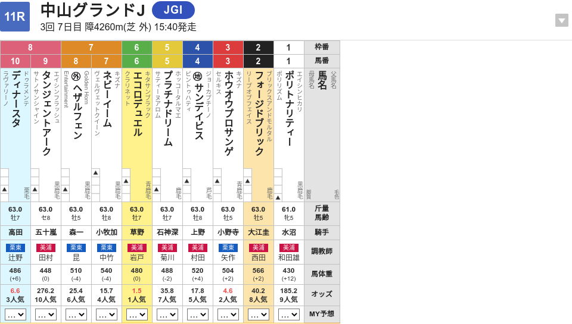

### 【アンタレスステークス 2026/04/18(土) 】

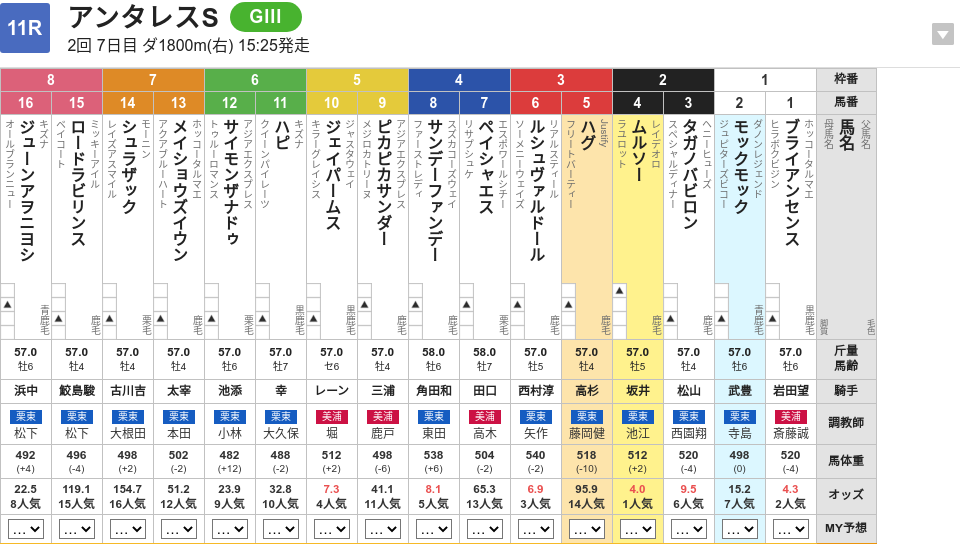

### 【皐月賞 2026/04/19(日) 】

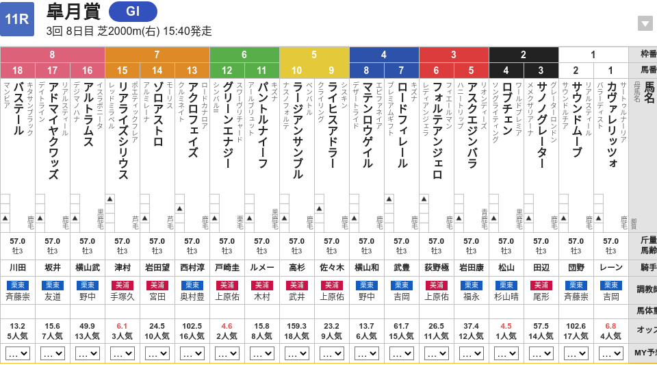

### 【福島牝馬ステークス 2026/04/19(日) 】

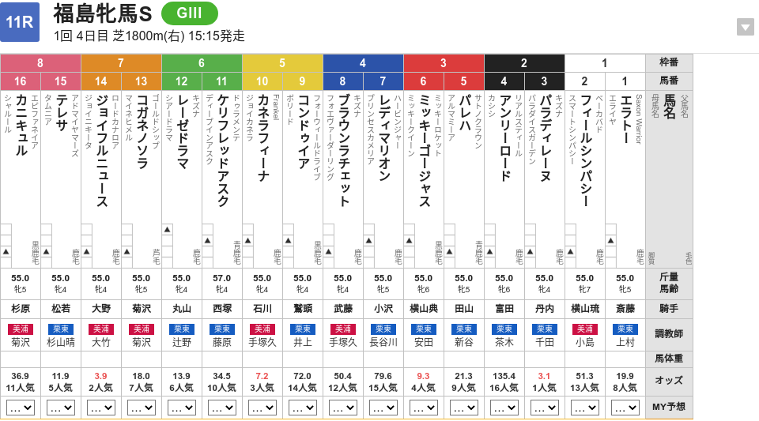

## 4. 単勝予測結果

### 【中山グランドジャンプ(J.GⅠ) 2026/04/18(土)】

| 枠番 | 馬番 | 人気 | オッズ | 馬名 | 騎手 | 調教師 | 予測タイム(sec) | 1_順位 | 1-3着内確率(%) | 2_順位 | ﾀﾞｰｸﾎｰｽ確率(%) | 3_順位 |
| --- | --- | --- | --- | --- | --- | --- | --- | --- | --- | --- | --- | --- |
| 1 | 1 | 9 | 185.2 | ポリトナリティー | 水沼元輝 | 和田雄二 | 301.1 | 4.0 | 13.8 | 7 | 55.7 | 1 |
| 2 | 2 | 8 | 40.2 | フォージドブリック | 大江原圭 | 西田雄一郎 | 302.1 | 6.5 | 17.6 | 6 | 40.2 | 3 |
| 3 | 3 | 2 | 4.6 | ホウオウプロサンゲ | 小野寺祐太 | 矢作芳人 | 302.1 | 6.5 | 19.0 | 5 | 0.6 | 9 |
| 4 | 4 | 5 | 17.8 | サンデイビス | 上野翔 | 村田一誠 | 303.9 | 9.0 | 23.8 | 3 | 1.8 | 6 |
| 5 | 5 | 7 | 35.8 | プラチナドリーム | 石神深一 | 菊川正達 | 303.2 | 8.0 | 6.7 | 10 | 15.7 | 5 |
| 6 | 6 | 1 | 1.5 | エコロデュエル | 草野太郎 | 岩戸孝樹 | 283.0 | 1.0 | 26.2 | 2 | 0.5 | 10 |
| 7 | 7 | 4 | 15.7 | ネビーイーム | 小牧加矢太 | 中竹和也 | 299.3 | 2.0 | 20.7 | 4 | 1.1 | 7 |
| 7 | 8 | 6 | 25.4 | ヘザルフェン | 森一馬 | 昆貢 | 305.8 | 10.0 | 8.8 | 9 | 18.4 | 4 |
| 8 | 9 | 10 | 276.2 | タンジェントアーク | 五十嵐雄祐 | 田村康仁 | 299.4 | 3.0 | 11.8 | 8 | 47.9 | 2 |
| 8 | 10 | 3 | 6.6 | ディナースタ | 高田潤 | 辻野泰之 | 301.5 | 5.0 | 29.6 | 1 | 0.7 | 8 |

### 【アンタレスステークス(GⅢ) 2026/04/18(土)】

| 枠番 | 馬番 | 人気 | オッズ | 馬名 | 騎手 | 調教師 | 予測タイム(sec) | 1_順位 | 1-3着内確率(%) | 2_順位 | ﾀﾞｰｸﾎｰｽ確率(%) | 3_順位 |
| --- | --- | --- | --- | --- | --- | --- | --- | --- | --- | --- | --- | --- |
| 1 | 1 | 2 | 4.3 | ブライアンセンス | 岩田望来 | 斎藤誠 | 118.2 | 12.0 | 45.0 | 1 | 0.4 | 15 |
| 1 | 2 | 7 | 15.2 | モックモック | 武豊 | 寺島良 | 120.1 | 15.0 | 30.7 | 3 | 0.8 | 12 |
| 2 | 3 | 6 | 9.5 | タガノバビロン | 松山弘平 | 西園翔太 | 110.4 | 7.0 | 25.7 | 4 | 1.1 | 10 |
| 2 | 4 | 1 | 4.0 | ムルソー | 坂井瑠星 | 池江泰寿 | 108.1 | 1.5 | 15.3 | 6 | 0.3 | 16 |
| 3 | 5 | 14 | 95.9 | ハグ | 高杉吏麒 | 藤岡健一 | 109.8 | 4.0 | 11.5 | 9 | 48.8 | 1 |
| 3 | 6 | 3 | 6.9 | ルシュヴァルドール | 西村淳也 | 矢作芳人 | 119.5 | 14.0 | 19.9 | 5 | 0.5 | 14 |
| 4 | 7 | 13 | 65.3 | ペイシャエス | 田口貫太 | 高木登 | 117.3 | 10.0 | 2.0 | 16 | 16.4 | 6 |
| 4 | 8 | 5 | 8.1 | サンデーファンデー | 角田大和 | 東田明士 | 116.7 | 8.0 | 8.9 | 11 | 1.0 | 11 |
| 5 | 9 | 11 | 41.1 | ピカピカサンダー | 三浦皇成 | 鹿戸雄一 | 108.8 | 3.0 | 13.3 | 7 | 33.5 | 4 |
| 5 | 10 | 4 | 7.3 | ジェイパームス | Ｄ．レーン | 堀宣行 | 108.1 | 1.5 | 32.0 | 2 | 0.6 | 13 |

[output cut: 6 more lines]

### 【皐月賞(GⅠ) 2026/04/19(日)】

| 枠番 | 馬番 | 人気 | オッズ | 馬名 | 騎手 | 調教師 | 予測タイム(sec) | 1_順位 | 1-3着内確率(%) | 2_順位 | ﾀﾞｰｸﾎｰｽ確率(%) | 3_順位 |
| --- | --- | --- | --- | --- | --- | --- | --- | --- | --- | --- | --- | --- |
| 1 | 1 | 4 | 6.8 | カヴァレリッツォ | Ｄ．レーン | 吉岡辰弥 | 125.2 | 12.0 | 28.6 | 2 | 0.6 | 18 |
| 1 | 2 | 17 | 103.4 | サウンドムーブ | 団野大成 | 斉藤崇史 | 124.7 | 6.0 | 6.0 | 17 | 29.4 | 7 |
| 2 | 3 | 14 | 57.4 | サノノグレーター | 田辺裕信 | 尾形和幸 | 125.2 | 12.0 | 12.2 | 13 | 46.5 | 2 |
| 2 | 4 | 1 | 4.5 | ロブチェン | 松山弘平 | 杉山晴紀 | 117.8 | 1.5 | 27.8 | 4 | 0.8 | 15 |
| 3 | 5 | 12 | 37.5 | アスクエジンバラ | 岩田康誠 | 福永祐一 | 124.9 | 8.0 | 11.9 | 14 | 45.1 | 3 |
| 3 | 6 | 11 | 26.4 | フォルテアンジェロ | 荻野極 | 上原佑紀 | 125.2 | 12.0 | 20.0 | 10 | 35.9 | 6 |
| 4 | 7 | 15 | 61.7 | ロードフィレール | 武豊 | 吉岡辰弥 | 125.5 | 16.0 | 6.6 | 16 | 54.9 | 1 |
| 4 | 8 | 6 | 13.8 | マテンロウゲイル | 横山和生 | 野中賢二 | 124.5 | 4.5 | 21.7 | 8 | 2.2 | 10 |
| 5 | 9 | 9 | 23.1 | ライヒスアドラー | 佐々木大輔 | 上原佑紀 | 125.2 | 12.0 | 22.3 | 7 | 2.0 | 13 |
| 5 | 10 | 18 | 160.3 | ラージアンサンブル | 高杉吏麒 | 武井亮 | 126.5 | 18.0 | 4.1 | 18 | 26.4 | 8 |

[output cut: 8 more lines]

### 【福島牝馬ステークス(GⅢ) 2026/04/19(日)】

| 枠番 | 馬番 | 人気 | オッズ | 馬名 | 騎手 | 調教師 | 予測タイム(sec) | 1_順位 | 1-3着内確率(%) | 2_順位 | ﾀﾞｰｸﾎｰｽ確率(%) | 3_順位 |
| --- | --- | --- | --- | --- | --- | --- | --- | --- | --- | --- | --- | --- |
| 1 | 1 | 9 | 20.7 | エラトー | 斎藤新 | 上村洋行 | 118.7 | 16 | 6.4 | 15 | 24.2 | 7 |
| 1 | 2 | 13 | 50.7 | フィールシンパシー | 横山琉人 | 小島茂之 | 111.8 | 11 | 7.1 | 13 | 47.1 | 2 |
| 2 | 3 | 1 | 3.1 | パラディレーヌ | 丹内祐次 | 千田輝彦 | 105.4 | 1 | 21.5 | 5 | 0.4 | 15 |
| 2 | 4 | 16 | 144.0 | アンリーロード | 富田暁 | 茶木太樹 | 115.4 | 13 | 7.0 | 14 | 12.4 | 8 |
| 3 | 5 | 8 | 20.6 | パレハ | 田山旺佑 | 新谷功一 | 117.1 | 15 | 3.8 | 16 | 1.0 | 14 |
| 3 | 6 | 4 | 9.9 | ミッキーゴージャス | 横山典弘 | 安田翔伍 | 110.3 | 9 | 25.9 | 3 | 1.1 | 12 |
| 4 | 7 | 15 | 79.0 | レディマリオン | 小沢大仁 | 長谷川浩大 | 112.2 | 12 | 8.0 | 11 | 48.1 | 1 |
| 4 | 8 | 12 | 48.2 | ブラウンラチェット | 武藤雅 | 手塚貴久 | 106.7 | 2 | 10.1 | 8 | 40.6 | 4 |
| 5 | 9 | 14 | 73.3 | コンドゥイア | 鷲頭虎太 | 井上智史 | 108.5 | 4 | 11.7 | 7 | 43.4 | 3 |
| 5 | 10 | 3 | 7.1 | カネラフィーナ | 石川裕紀人 | 手塚貴久 | 108.8 | 6 | 29.8 | 2 | 1.0 | 13 |

[output cut: 6 more lines]

## 5. 人気と着順の乖離率推移

### 【中山グランドジャンプ_1999y_2019y】

[interactive chart not shown]

### 【アンタレスステークス_1996y_2019y】

[interactive chart not shown]

### 【皐月賞_1990y_2019y】

[interactive chart not shown]

### 【福島牝馬ステークス_2004y_2019y】

[interactive chart not shown]

### 【中山グランドジャンプ_1999y_2019y】

| No | 開催年 | 不整合率(%) | 頭数 | 人気別着順(1-3位) | 人気別着順(全体) |
| --- | --- | --- | --- | --- | --- |
| 21 | 2019 | 39.0 | 9頭 | 1-6-4 | 1\|6\|4\|8\|3\|2\|7\|5\|11 |
| 20 | 2018 | 11.2 | 12頭 | 1-2-3 | 1\|2\|3\|5\|11\|8\|6\|9\|7\|10\|12\|4 |
| 19 | 2017 | 24.8 | 13頭 | 1-6-2 | 1\|6\|2\|5\|4\|11\|8\|7\|10\|13\|9\|12\|3 |
| 18 | 2016 | 29.1 | 9頭 | 2-1-7 | 2\|1\|7\|10\|3\|9\|8\|6\|4 |
| 17 | 2015 | 76.3 | 10頭 | 4-5-3 | 4\|5\|3\|6\|2\|11\|1\|14\|12\|15 |
| 16 | 2014 | 30.0 | 10頭 | 1-8-3 | 1\|8\|3\|5\|6\|2\|7\|4\|10\|9 |
| 15 | 2013 | 39.8 | 13頭 | 8-2-3 | 8\|2\|3\|13\|7\|1\|4\|10\|6\|12\|11\|14\|5 |
| 14 | 2012 | 19.6 | 13頭 | 1-2-8 | 1\|2\|8\|6\|12\|4\|11\|13\|3\|7\|10\|5\|9 |
| 13 | 2011 | 31.4 | 10頭 | 2-5-8 | 2\|5\|8\|1\|3\|4\|11\|10\|12\|9 |
| 12 | 2010 | 49.6 | 13頭 | 8-5-2 | 8\|5\|2\|12\|7\|4\|13\|10\|6\|9\|3\|11\|14 |

[output cut: 11 more lines]

### 【アンタレスステークス_1996y_2019y】

| No | 開催年 | 不整合率(%) | 頭数 | 人気別着順(1-3位) | 人気別着順(全体) |
| --- | --- | --- | --- | --- | --- |
| 24 | 2019 | 38.8 | 16頭 | 6-2-3 | 6\|2\|3\|1\|7\|10\|9\|4\|14\|12\|8\|5\|11\|16\|13\|15 |
| 23 | 2018 | 28.5 | 16頭 | 1-3-5 | 1\|3\|5\|4\|7\|6\|9\|2\|16\|14\|8\|13\|10\|12\|15\|11 |
| 22 | 2017 | 53.0 | 16頭 | 3-6-8 | 3\|6\|8\|13\|4\|12\|10\|9\|1\|16\|2\|11\|15\|7\|5\|14 |
| 21 | 2016 | 27.5 | 16頭 | 1-3-5 | 1\|3\|5\|4\|2\|11\|7\|8\|16\|9\|13\|10\|14\|15\|12\|6 |
| 20 | 2015 | 21.4 | 16頭 | 6-1-2 | 6\|1\|2\|9\|10\|3\|13\|7\|5\|11\|15\|14\|4\|8\|16\|12 |
| 19 | 2014 | 30.2 | 16頭 | 2-5-1 | 2\|5\|1\|12\|7\|3\|10\|15\|16\|6\|13\|4\|14\|8\|11\|9 |
| 18 | 2013 | 11.3 | 16頭 | 1-2-3 | 1\|2\|3\|8\|6\|11\|4\|14\|5\|13\|9\|12\|10\|16\|15\|7 |
| 17 | 2012 | 22.1 | 16頭 | 1-11-3 | 1\|11\|3\|13\|2\|5\|4\|10\|7\|15\|6\|14\|16\|12\|8\|9 |
| 16 | 2011 | 37.8 | 12頭 | 3-1-2 | 3\|1\|2\|5\|13\|10\|8\|11\|9\|7\|4\|6 |
| 15 | 2010 | 55.9 | 15頭 | 4-5-2 | 4\|5\|2\|10\|3\|14\|8\|1\|11\|13\|7\|15\|9\|6\|12 |

[output cut: 14 more lines]

### 【皐月賞_1990y_2019y】

| No | 開催年 | 不整合率(%) | 頭数 | 人気別着順(1-3位) | 人気別着順(全体) |
| --- | --- | --- | --- | --- | --- |
| 30 | 2019 | 31.5 | 18頭 | 1-4-3 | 1\|4\|3\|2\|14\|15\|10\|11\|17\|18\|13\|7\|5\|8\|9\|16\|6\|12 |
| 29 | 2018 | 42.9 | 16頭 | 7-9-8 | 7\|9\|8\|2\|3\|10\|1\|12\|4\|6\|11\|5\|13\|14\|15\|16 |
| 28 | 2017 | 45.7 | 18頭 | 9-4-12 | 9\|4\|12\|13\|5\|2\|1\|6\|3\|10\|8\|7\|17\|16\|18\|14\|11\|15 |
| 27 | 2016 | 35.2 | 18頭 | 8-3-1 | 8\|3\|1\|4\|2\|6\|9\|5\|7\|16\|10\|11\|14\|18\|13\|12\|15\|17 |
| 26 | 2015 | 49.6 | 15頭 | 3-2-4 | 3\|2\|4\|6\|10\|1\|11\|9\|8\|15\|5\|7\|12\|13\|14 |
| 25 | 2014 | 31.4 | 18頭 | 2-1-8 | 2\|1\|8\|4\|15\|5\|13\|10\|7\|6\|3\|12\|18\|14\|11\|9\|16\|17 |
| 24 | 2013 | 12.9 | 18頭 | 1-2-3 | 1\|2\|3\|4\|8\|14\|15\|12\|10\|9\|16\|7\|5\|13\|17\|11\|18\|6 |
| 23 | 2012 | 48.0 | 18頭 | 4-2-3 | 4\|2\|3\|6\|1\|9\|13\|11\|16\|18\|8\|7\|17\|15\|14\|10\|12\|5 |
| 22 | 2011 | 29.2 | 18頭 | 4-1-8 | 4\|1\|8\|14\|2\|15\|5\|16\|13\|7\|3\|11\|6\|12\|9\|17\|18\|10 |
| 21 | 2010 | 19.4 | 18頭 | 1-6-11 | 1\|6\|11\|2\|3\|5\|12\|10\|9\|13\|4\|16\|14\|18\|15\|17\|8\|7 |

[output cut: 20 more lines]

### 【福島牝馬ステークス_2004y_2019y】

| No | 開催年 | 不整合率(%) | 頭数 | 人気別着順(1-3位) | 人気別着順(全体) |
| --- | --- | --- | --- | --- | --- |
| 16 | 2019 | 26.4 | 10頭 | 4-1-2 | 4\|1\|2\|9\|8\|3\|6\|7\|5\|10 |
| 15 | 2018 | 22.5 | 12頭 | 7-1-4 | 7\|1\|4\|2\|3\|6\|10\|8\|5\|9\|12\|11 |
| 14 | 2017 | 44.2 | 16頭 | 3-4-1 | 3\|4\|1\|8\|16\|10\|2\|13\|7\|6\|9\|12\|14\|5\|11\|15 |
| 13 | 2016 | 24.2 | 16頭 | 15-1-13 | 15\|1\|13\|3\|8\|2\|7\|4\|6\|5\|10\|11\|14\|12\|9\|16 |
| 12 | 2015 | 48.3 | 16頭 | 3-9-13 | 3\|9\|13\|12\|14\|8\|1\|10\|6\|4\|2\|16\|5\|15\|7\|11 |
| 11 | 2014 | 47.5 | 16頭 | 5-2-16 | 5\|2\|16\|10\|7\|11\|3\|14\|8\|1\|12\|4\|15\|6\|13\|9 |
| 10 | 2013 | 20.9 | 15頭 | 1-3-10 | 1\|3\|10\|2\|4\|9\|11\|6\|7\|5\|8\|14\|12\|15\|13 |
| 9 | 2012 | 14.8 | 16頭 | 1-4-2 | 1\|4\|2\|3\|6\|8\|5\|7\|10\|11\|14\|9\|16\|15\|12\|13 |
| 8 | 2011 | 51.7 | 16頭 | 9-5-3 | 9\|5\|3\|7\|10\|6\|1\|2\|4\|15\|12\|14\|11\|8\|16\|13 |
| 7 | 2010 | 69.2 | 16頭 | 5-4-3 | 5\|4\|3\|12\|11\|2\|7\|13\|14\|6\|15\|1\|16\|8\|9\|10 |

[output cut: 6 more lines]

## 6. 1-3番人気馬の着順分類予測

### 【中山グランドジャンプ】

| 分類 | 凡例 | 発生確率(%) | 当該レース | 当該レースランク | 直近1年間 |
| --- | --- | --- | --- | --- | --- |
| 4: 1,2番人気のみ (4_pop12) | 1 \| 2 \| * | 18.2 | 0.98 | 1.92 | 0.73 |
| 1: 1番人気のみ (1_pop1) | 1 \| * \| * | 17.3 | 0.52 | 0.60 | 0.69 |
| 5: 1,3番人気のみ (5_pop13) | 1 \| 3 \| * | 15.4 | 4.16 | 0.97 | 0.62 |
| 8: 1,2,3番人気すべて着外 (8_darkhorse) | * \| * \| * | 11.7 | 0.79 | 0.92 | 0.00 |
| 2: 2番人気のみ (2_pop2) | 2 \| * \| * | 10.2 | 0.92 | 1.07 | 0.00 |
| 6: 2,3番人気のみ (6_pop23) | 2 \| 3 \| * | 9.9 | 1.34 | 1.25 | 0.40 |
| 3: 3番人気のみ (3_pop3) | 3 \| * \| * | 9.0 | 2.43 | 1.88 | 0.00 |
| 7: 1,2,3番人気すべて着内 (7_pop123) | 1 \| 2 \| 3 | 8.3 | 1.12 | 0.75 | 0.00 |

### 【アンタレスステークス】

| 分類 | 凡例 | 発生確率(%) | 当該レース | 当該レースランク | 直近1年間 |
| --- | --- | --- | --- | --- | --- |
| 4: 1,2番人気のみ (4_pop12) | 1 \| 2 \| * | 17.7 | 1.06 | 0.71 | 0.71 |
| 1: 1番人気のみ (1_pop1) | 1 \| * \| * | 17.3 | 2.58 | 1.80 | 0.69 |
| 8: 1,2,3番人気すべて着外 (8_darkhorse) | * \| * \| * | 13.9 | 0.83 | 1.03 | 0.00 |
| 6: 2,3番人気のみ (6_pop23) | 2 \| 3 \| * | 13.5 | 0.51 | 0.88 | 0.54 |
| 5: 1,3番人気のみ (5_pop13) | 1 \| 3 \| * | 13.2 | 1.32 | 1.15 | 0.53 |
| 2: 2番人気のみ (2_pop2) | 2 \| * \| * | 9.1 | 2.76 | 1.18 | 0.00 |
| 3: 3番人気のみ (3_pop3) | 3 \| * \| * | 8.3 | 1.24 | 0.86 | 0.00 |
| 7: 1,2,3番人気すべて着内 (7_pop123) | 1 \| 2 \| 3 | 7.0 | 0.53 | 0.91 | 0.00 |

### 【皐月賞】

| 分類 | 凡例 | 発生確率(%) | 当該レース | 当該レースランク | 直近1年間 |
| --- | --- | --- | --- | --- | --- |
| 4: 1,2番人気のみ (4_pop12) | 1 \| 2 \| * | 18.2 | 6.50 | 6.50 | 0.36 |
| 1: 1番人気のみ (1_pop1) | 1 \| * \| * | 17.3 | 0.69 | 0.69 | 0.00 |
| 5: 1,3番人気のみ (5_pop13) | 1 \| 3 \| * | 15.4 | 0.62 | 0.62 | 0.31 |
| 8: 1,2,3番人気すべて着外 (8_darkhorse) | * \| * \| * | 11.7 | 1.05 | 1.05 | 0.00 |
| 2: 2番人気のみ (2_pop2) | 2 \| * \| * | 10.2 | 1.23 | 1.23 | 0.00 |
| 6: 2,3番人気のみ (6_pop23) | 2 \| 3 \| * | 9.9 | 1.19 | 1.19 | 0.00 |
| 3: 3番人気のみ (3_pop3) | 3 \| * \| * | 9.0 | 1.61 | 1.61 | 0.00 |
| 7: 1,2,3番人気すべて着内 (7_pop123) | 1 \| 2 \| 3 | 8.3 | 0.60 | 0.60 | 0.00 |

### 【福島牝馬ステークス】

| 分類 | 凡例 | 発生確率(%) | 当該レース | 当該レースランク | 直近1年間 |
| --- | --- | --- | --- | --- | --- |
| 4: 1,2番人気のみ (4_pop12) | 1 \| 2 \| * | 17.7 | 0.49 | 0.49 | 0.35 |
| 1: 1番人気のみ (1_pop1) | 1 \| * \| * | 17.3 | 1.27 | 1.27 | 0.00 |
| 8: 1,2,3番人気すべて着外 (8_darkhorse) | * \| * \| * | 13.9 | 1.53 | 1.53 | 0.00 |
| 6: 2,3番人気のみ (6_pop23) | 2 \| 3 \| * | 13.5 | 0.00 | 0.00 | 0.00 |
| 5: 1,3番人気のみ (5_pop13) | 1 \| 3 \| * | 13.2 | 0.97 | 0.97 | 0.26 |
| 2: 2番人気のみ (2_pop2) | 2 \| * \| * | 9.1 | 0.67 | 0.67 | 0.00 |
| 3: 3番人気のみ (3_pop3) | 3 \| * \| * | 8.3 | 0.61 | 0.61 | 0.00 |
| 7: 1,2,3番人気すべて着内 (7_pop123) | 1 \| 2 \| 3 | 7.0 | 0.00 | 0.00 | 0.00 |

## 7. 3連複予測結果

### 【中山グランドジャンプ(J.GⅠ) 2026/04/18(土)】

| 分類 | 馬番 | 枠番 | 人気 | 平均予測タイム(sec) | 1-3着内確率(%) | ﾀﾞｰｸﾎｰｽ確率(%) | 馬名 | 騎手 | 調教師 |
| --- | --- | --- | --- | --- | --- | --- | --- | --- | --- |
| 5: 1,3番人気のみ (5_pop13) | 6-10-4 | 6-8-4 | 1-3-5 | 296.13 | 1.85 | 0.00 | エコロデュエル \| ディナースタ \| サンデイビス | 草野太郎 \| 高田潤 \| 上野翔 | 岩戸孝樹 \| 辻野泰之 \| 村田一誠 |
| 5: 1,3番人気のみ (5_pop13) | 6-10-7 | 6-8-7 | 1-3-4 | 294.60 | 1.61 | 0.00 | エコロデュエル \| ディナースタ \| ネビーイーム | 草野太郎 \| 高田潤 \| 小牧加矢太 | 岩戸孝樹 \| 辻野泰之 \| 中竹和也 |
| 7: 1,2,3番人気すべて着内 (7_pop123) | 6-3-10 | 6-3-8 | 1-2-3 | 295.53 | 1.47 | 0.00 | エコロデュエル \| ホウオウプロサンゲ \| ディナースタ | 草野太郎 \| 小野寺祐太 \| 高田潤 | 岩戸孝樹 \| 矢作芳人 \| 辻野泰之 |
| 3: 3番人気のみ (3_pop3) | 10-7-4 | 8-7-4 | 3-4-5 | 301.57 | 1.46 | 0.00 | ディナースタ \| ネビーイーム \| サンデイビス | 高田潤 \| 小牧加矢太 \| 上野翔 | 辻野泰之 \| 中竹和也 \| 村田一誠 |
| 5: 1,3番人気のみ (5_pop13) | 6-10-2 | 6-8-2 | 1-3-8 | 295.53 | 1.37 | 0.00 | エコロデュエル \| ディナースタ \| フォージドブリック | 草野太郎 \| 高田潤 \| 大江原圭 | 岩戸孝樹 \| 辻野泰之 \| 西田雄一郎 |
| 6: 2,3番人気のみ (6_pop23) | 3-10-4 | 3-8-4 | 2-3-5 | 302.50 | 1.34 | 0.00 | ホウオウプロサンゲ \| ディナースタ \| サンデイビス | 小野寺祐太 \| 高田潤 \| 上野翔 | 矢作芳人 \| 辻野泰之 \| 村田一誠 |
| 1: 1番人気のみ (1_pop1) | 6-7-4 | 6-7-4 | 1-4-5 | 295.40 | 1.29 | 0.00 | エコロデュエル \| ネビーイーム \| サンデイビス | 草野太郎 \| 小牧加矢太 \| 上野翔 | 岩戸孝樹 \| 中竹和也 \| 村田一誠 |
| 3: 3番人気のみ (3_pop3) | 10-4-2 | 8-4-2 | 3-5-8 | 302.50 | 1.25 | 0.00 | ディナースタ \| サンデイビス \| フォージドブリック | 高田潤 \| 上野翔 \| 大江原圭 | 辻野泰之 \| 村田一誠 \| 西田雄一郎 |
| 4: 1,2番人気のみ (4_pop12) | 6-3-4 | 6-3-4 | 1-2-5 | 296.33 | 1.18 | 0.00 | エコロデュエル \| ホウオウプロサンゲ \| サンデイビス | 草野太郎 \| 小野寺祐太 \| 上野翔 | 岩戸孝樹 \| 矢作芳人 \| 村田一誠 |
| 6: 2,3番人気のみ (6_pop23) | 3-10-7 | 3-8-7 | 2-3-4 | 300.97 | 1.16 | 0.00 | ホウオウプロサンゲ \| ディナースタ \| ネビーイーム | 小野寺祐太 \| 高田潤 \| 小牧加矢太 | 矢作芳人 \| 辻野泰之 \| 中竹和也 |

[output cut: 110 more lines]

### 【アンタレスステークス(GⅢ) 2026/04/18(土)】

| 分類 | 馬番 | 枠番 | 人気 | 平均予測タイム(sec) | 1-3着内確率(%) | ﾀﾞｰｸﾎｰｽ確率(%) | 馬名 | 騎手 | 調教師 |
| --- | --- | --- | --- | --- | --- | --- | --- | --- | --- |
| 2: 2番人気のみ (2_pop2) | 1-10-2 | 1-5-1 | 2-4-7 | 115.47 | 4.41 | 0.00 | ブライアンセンス \| ジェイパームス \| モックモック | 岩田望来 \| Ｄ．レーン \| 武豊 | 斎藤誠 \| 堀宣行 \| 寺島良 |
| 2: 2番人気のみ (2_pop2) | 1-10-3 | 1-5-2 | 2-4-6 | 112.23 | 3.70 | 0.00 | ブライアンセンス \| ジェイパームス \| タガノバビロン | 岩田望来 \| Ｄ．レーン \| 松山弘平 | 斎藤誠 \| 堀宣行 \| 西園翔太 |
| 2: 2番人気のみ (2_pop2) | 1-3-2 | 1-2-1 | 2-6-7 | 116.23 | 3.55 | 0.00 | ブライアンセンス \| タガノバビロン \| モックモック | 岩田望来 \| 松山弘平 \| 武豊 | 斎藤誠 \| 西園翔太 \| 寺島良 |
| 6: 2,3番人気のみ (6_pop23) | 1-6-10 | 1-3-5 | 2-3-4 | 115.27 | 2.87 | 0.00 | ブライアンセンス \| ルシュヴァルドール \| ジェイパームス | 岩田望来 \| 西村淳也 \| Ｄ．レーン | 斎藤誠 \| 矢作芳人 \| 堀宣行 |
| 6: 2,3番人気のみ (6_pop23) | 1-6-2 | 1-3-1 | 2-3-7 | 119.27 | 2.75 | 0.00 | ブライアンセンス \| ルシュヴァルドール \| モックモック | 岩田望来 \| 西村淳也 \| 武豊 | 斎藤誠 \| 矢作芳人 \| 寺島良 |
| 8: 1,2,3番人気すべて着外 (8_darkhorse) | 10-3-2 | 5-2-1 | 4-6-7 | 112.87 | 2.52 | 0.00 | ジェイパームス \| タガノバビロン \| モックモック | Ｄ．レーン \| 松山弘平 \| 武豊 | 堀宣行 \| 西園翔太 \| 寺島良 |
| 6: 2,3番人気のみ (6_pop23) | 1-6-3 | 1-3-2 | 2-3-6 | 116.03 | 2.31 | 0.00 | ブライアンセンス \| ルシュヴァルドール \| タガノバビロン | 岩田望来 \| 西村淳也 \| 松山弘平 | 斎藤誠 \| 矢作芳人 \| 西園翔太 |
| 4: 1,2番人気のみ (4_pop12) | 4-1-10 | 2-1-5 | 1-2-4 | 111.47 | 2.20 | 0.00 | ムルソー \| ブライアンセンス \| ジェイパームス | 坂井瑠星 \| 岩田望来 \| Ｄ．レーン | 池江泰寿 \| 斎藤誠 \| 堀宣行 |
| 4: 1,2番人気のみ (4_pop12) | 4-1-2 | 2-1-1 | 1-2-7 | 115.47 | 2.11 | 0.00 | ムルソー \| ブライアンセンス \| モックモック | 坂井瑠星 \| 岩田望来 \| 武豊 | 池江泰寿 \| 斎藤誠 \| 寺島良 |
| 3: 3番人気のみ (3_pop3) | 6-10-2 | 3-5-1 | 3-4-7 | 115.90 | 1.96 | 0.00 | ルシュヴァルドール \| ジェイパームス \| モックモック | 西村淳也 \| Ｄ．レーン \| 武豊 | 矢作芳人 \| 堀宣行 \| 寺島良 |

[output cut: 550 more lines]

### 【皐月賞(GⅠ) 2026/04/19(日)】

| 分類 | 馬番 | 枠番 | 人気 | 平均予測タイム(sec) | 1-3着内確率(%) | ﾀﾞｰｸﾎｰｽ確率(%) | 馬名 | 騎手 | 調教師 |
| --- | --- | --- | --- | --- | --- | --- | --- | --- | --- |
| 8: 1,2,3番人気すべて着外 (8_darkhorse) | 1-18-11 | 1-8-6 | 4-5-7 | 124.97 | 2.77 | 0.00 | カヴァレリッツォ \| バステール \| パントルナイーフ | Ｄ．レーン \| 川田将雅 \| Ｃ．ルメール | 吉岡辰弥 \| 斉藤崇史 \| 木村哲也 |
| 1: 1番人気のみ (1_pop1) | 4-1-11 | 2-1-6 | 1-4-7 | 122.73 | 2.73 | 0.00 | ロブチェン \| カヴァレリッツォ \| パントルナイーフ | 松山弘平 \| Ｄ．レーン \| Ｃ．ルメール | 杉山晴紀 \| 吉岡辰弥 \| 木村哲也 |
| 1: 1番人気のみ (1_pop1) | 4-18-11 | 2-8-6 | 1-5-7 | 122.50 | 2.69 | 0.00 | ロブチェン \| バステール \| パントルナイーフ | 松山弘平 \| 川田将雅 \| Ｃ．ルメール | 杉山晴紀 \| 斉藤崇史 \| 木村哲也 |
| 3: 3番人気のみ (3_pop3) | 15-1-11 | 7-1-6 | 3-4-7 | 125.10 | 2.65 | 0.00 | リアライズシリウス \| カヴァレリッツォ \| パントルナイーフ | 津村明秀 \| Ｄ．レーン \| Ｃ．ルメール | 手塚貴久 \| 吉岡辰弥 \| 木村哲也 |
| 3: 3番人気のみ (3_pop3) | 15-18-11 | 7-8-6 | 3-5-7 | 124.87 | 2.61 | 0.00 | リアライズシリウス \| バステール \| パントルナイーフ | 津村明秀 \| 川田将雅 \| Ｃ．ルメール | 手塚貴久 \| 斉藤崇史 \| 木村哲也 |
| 8: 1,2,3番人気すべて着外 (8_darkhorse) | 1-11-17 | 1-6-8 | 4-7-8 | 125.20 | 2.57 | 0.00 | カヴァレリッツォ \| パントルナイーフ \| アドマイヤクワッズ | Ｄ．レーン \| Ｃ．ルメール \| 坂井瑠星 | 吉岡辰弥 \| 木村哲也 \| 友道康夫 |
| 5: 1,3番人気のみ (5_pop13) | 4-15-11 | 2-7-6 | 1-3-7 | 122.63 | 2.57 | 0.00 | ロブチェン \| リアライズシリウス \| パントルナイーフ | 松山弘平 \| 津村明秀 \| Ｃ．ルメール | 杉山晴紀 \| 手塚貴久 \| 木村哲也 |
| 8: 1,2,3番人気すべて着外 (8_darkhorse) | 18-11-17 | 8-6-8 | 5-7-8 | 124.97 | 2.53 | 0.00 | バステール \| パントルナイーフ \| アドマイヤクワッズ | 川田将雅 \| Ｃ．ルメール \| 坂井瑠星 | 斉藤崇史 \| 木村哲也 \| 友道康夫 |
| 1: 1番人気のみ (1_pop1) | 4-11-17 | 2-6-8 | 1-7-8 | 122.73 | 2.50 | 0.00 | ロブチェン \| パントルナイーフ \| アドマイヤクワッズ | 松山弘平 \| Ｃ．ルメール \| 坂井瑠星 | 杉山晴紀 \| 木村哲也 \| 友道康夫 |
| 3: 3番人気のみ (3_pop3) | 15-11-17 | 7-6-8 | 3-7-8 | 125.10 | 2.42 | 0.00 | リアライズシリウス \| パントルナイーフ \| アドマイヤクワッズ | 津村明秀 \| Ｃ．ルメール \| 坂井瑠星 | 手塚貴久 \| 木村哲也 \| 友道康夫 |

[output cut: 806 more lines]

### 【福島牝馬ステークス(GⅢ) 2026/04/19(日)】

| 分類 | 馬番 | 枠番 | 人気 | 平均予測タイム(sec) | 1-3着内確率(%) | ﾀﾞｰｸﾎｰｽ確率(%) | 馬名 | 騎手 | 調教師 |
| --- | --- | --- | --- | --- | --- | --- | --- | --- | --- |
| 6: 2,3番人気のみ (6_pop23) | 14-10-6 | 7-5-3 | 2-3-4 | 109.53 | 3.64 | 0.00 | ジョイフルニュース \| カネラフィーナ \| ミッキーゴージャス | 大野拓弥 \| 石川裕紀人 \| 横山典弘 | 大竹正博 \| 手塚貴久 \| 安田翔伍 |
| 6: 2,3番人気のみ (6_pop23) | 14-10-15 | 7-5-8 | 2-3-5 | 109.07 | 3.28 | 0.00 | ジョイフルニュース \| カネラフィーナ \| テレサ | 大野拓弥 \| 石川裕紀人 \| 松若風馬 | 大竹正博 \| 手塚貴久 \| 杉山晴紀 |
| 7: 1,2,3番人気すべて着内 (7_pop123) | 3-14-10 | 2-7-5 | 1-2-3 | 107.90 | 3.02 | 0.00 | パラディレーヌ \| ジョイフルニュース \| カネラフィーナ | 丹内祐次 \| 大野拓弥 \| 石川裕紀人 | 千田輝彦 \| 大竹正博 \| 手塚貴久 |
| 6: 2,3番人気のみ (6_pop23) | 14-10-12 | 7-5-6 | 2-3-6 | 109.03 | 2.87 | 0.00 | ジョイフルニュース \| カネラフィーナ \| レーゼドラマ | 大野拓弥 \| 石川裕紀人 \| 丸山元気 | 大竹正博 \| 手塚貴久 \| 辻野泰之 |
| 2: 2番人気のみ (2_pop2) | 14-6-15 | 7-3-8 | 2-4-5 | 109.57 | 2.84 | 0.00 | ジョイフルニュース \| ミッキーゴージャス \| テレサ | 大野拓弥 \| 横山典弘 \| 松若風馬 | 大竹正博 \| 安田翔伍 \| 杉山晴紀 |
| 4: 1,2番人気のみ (4_pop12) | 3-14-6 | 2-7-3 | 1-2-4 | 108.40 | 2.62 | 0.00 | パラディレーヌ \| ジョイフルニュース \| ミッキーゴージャス | 丹内祐次 \| 大野拓弥 \| 横山典弘 | 千田輝彦 \| 大竹正博 \| 安田翔伍 |
| 2: 2番人気のみ (2_pop2) | 14-6-12 | 7-3-6 | 2-4-6 | 109.53 | 2.49 | 0.00 | ジョイフルニュース \| ミッキーゴージャス \| レーゼドラマ | 大野拓弥 \| 横山典弘 \| 丸山元気 | 大竹正博 \| 安田翔伍 \| 辻野泰之 |
| 4: 1,2番人気のみ (4_pop12) | 3-14-15 | 2-7-8 | 1-2-5 | 107.93 | 2.36 | 0.00 | パラディレーヌ \| ジョイフルニュース \| テレサ | 丹内祐次 \| 大野拓弥 \| 松若風馬 | 千田輝彦 \| 大竹正博 \| 杉山晴紀 |
| 2: 2番人気のみ (2_pop2) | 14-15-12 | 7-8-6 | 2-5-6 | 109.07 | 2.25 | 0.00 | ジョイフルニュース \| テレサ \| レーゼドラマ | 大野拓弥 \| 松若風馬 \| 丸山元気 | 大竹正博 \| 杉山晴紀 \| 辻野泰之 |
| 4: 1,2番人気のみ (4_pop12) | 3-14-12 | 2-7-6 | 1-2-6 | 107.90 | 2.07 | 0.00 | パラディレーヌ \| ジョイフルニュース \| レーゼドラマ | 丹内祐次 \| 大野拓弥 \| 丸山元気 | 千田輝彦 \| 大竹正博 \| 辻野泰之 |

[output cut: 550 more lines]

## 8. 直近の全レース情報

[output not shown]

[output cut: 1 more lines]